# Naive Bayes Classifier

Prajwal C N

04/03/2021

#### Loading R libraries

```r
library(readr)
library(reshape2)
library(dplyr)
library(e1071)
library(ggplot2)
library(caret)
library(class)
library(gmodels)
library(pROC)
```

#### Importing the UniversalBank dataset

```r
UniversalBank <- read_csv("UniversalBank.csv")
```

Given we focus on two predictors: Online and Credit Card, and the outcome Personal Loan. So Converting these variables to factors

```r
UniversalBank <- UniversalBank %>% mutate(`Personal Loan` = as.factor(`Personal Loan`),
                         Online = as.factor(Online),
                         CreditCard = as.factor(CreditCard))

#Examining the dataset
glimpse(UniversalBank)
```

```
## Rows: 5,000
## Columns: 14
## $ ID                   <dbl> 1, 2, 3, 4, 5, 6, 7, 8, 9, 10, 11, 12, 13, 14,...
## $ Age                  <dbl> 25, 45, 39, 35, 35, 37, 53, 50, 35, 34, 65, 29...
## $ Experience           <dbl> 1, 19, 15, 9, 8, 13, 27, 24, 10, 9, 39, 5, 23,...
## $ Income               <dbl> 49, 34, 11, 100, 45, 29, 72, 22, 81, 180, 105,...
## $ `ZIP Code`           <dbl> 91107, 90089, 94720, 94112, 91330, 92121, 9171...
## $ Family               <dbl> 4, 3, 1, 1, 4, 4, 2, 1, 3, 1, 4, 3, 2, 4, 1, 1...
## $ CCAvg                <dbl> 1.6, 1.5, 1.0, 2.7, 1.0, 0.4, 1.5, 0.3, 0.6, 8...
## $ Education            <dbl> 1, 1, 1, 2, 2, 2, 2, 3, 2, 3, 3, 2, 3, 2, 1, 3...
## $ Mortgage             <dbl> 0, 0, 0, 0, 0, 155, 0, 0, 104, 0, 0, 0, 0, 0, ...
## $ `Personal Loan`      <fct> 0, 0, 0, 0, 0, 0, 0, 0, 0, 1, 0, 0, 0, 0, 0, 0...
## $ `Securities Account` <dbl> 1, 1, 0, 0, 0, 0, 0, 0, 0, 0, 0, 0, 1, 0, 1, 0...
## $ `CD Account`         <dbl> 0, 0, 0, 0, 0, 0, 0, 0, 0, 0, 0, 0, 0, 0, 0, 0...
## $ Online               <fct> 0, 0, 0, 0, 0, 1, 1, 0, 1, 0, 0, 1, 0, 1, 0, 1...
## $ CreditCard           <fct> 0, 0, 0, 0, 1, 0, 0, 1, 0, 0, 0, 0, 0, 0, 0, 1...
```

#### Data cleaning and Exploratory Data Analysis

Checking summary for each categorical variable

```r
summary(UniversalBank %>%  select(`Personal Loan`, Online, CreditCard))
```

```
##  Personal Loan Online   CreditCard
##  0:4520        0:2016   0:3530
##  1: 480        1:2984   1:1470
```

Checking NULL values in the dataset at column level.

```r
apply(UniversalBank,2,function(x){any(is.na(x))})
```

```
##                 ID                Age         Experience             Income
##              FALSE              FALSE              FALSE              FALSE
##           ZIP Code             Family              CCAvg          Education
##              FALSE              FALSE              FALSE              FALSE
##           Mortgage      Personal Loan Securities Account         CD Account
##              FALSE              FALSE              FALSE              FALSE
##             Online         CreditCard
##              FALSE              FALSE
```

**Visualization**

Visualizing distribution of each categorical variable.

1. Credit Card category

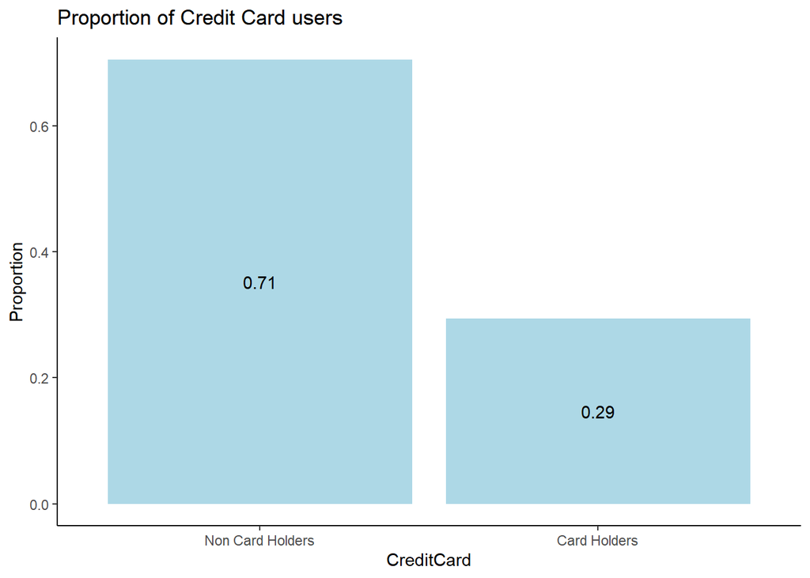

```r
ggplot(UniversalBank, aes(x=CreditCard, y=..prop..,group = 1)) +
  geom_bar(fill="light blue") +
  theme_classic() +
  geom_text(aes(label=round(..prop..,2)),stat = "count",
            position = position_stack(vjust=0.5)) +
  labs(y = 'Proportion', title = "Proportion of Credit Card users") +
  scale_x_discrete(labels = c("Non Card Holders","Card Holders"))
```

From the above graph we can infer that majority of population don’t hold credit card, only 29% have it.

2. Personal Loan category

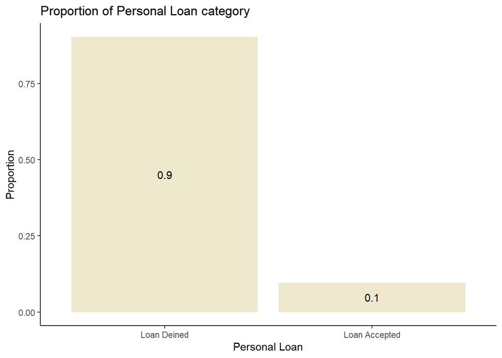

```r
ggplot(UniversalBank, aes(x=`Personal Loan`, y=..prop..,group = 1)) +
  geom_bar(fill="cornsilk2") +
  theme_classic() +
  geom_text(aes(label=round(..prop..,2)),stat = "count",
            position = position_stack(vjust=0.5)) +
  labs(y = 'Proportion', title = "Proportion of Personal Loan category") +
  scale_x_discrete(labels = c("Loan Deined","Loan Accepted"))
```

From the above graph we can see that only around 10% of population accepted loan and rest rejected it.

3. Online category

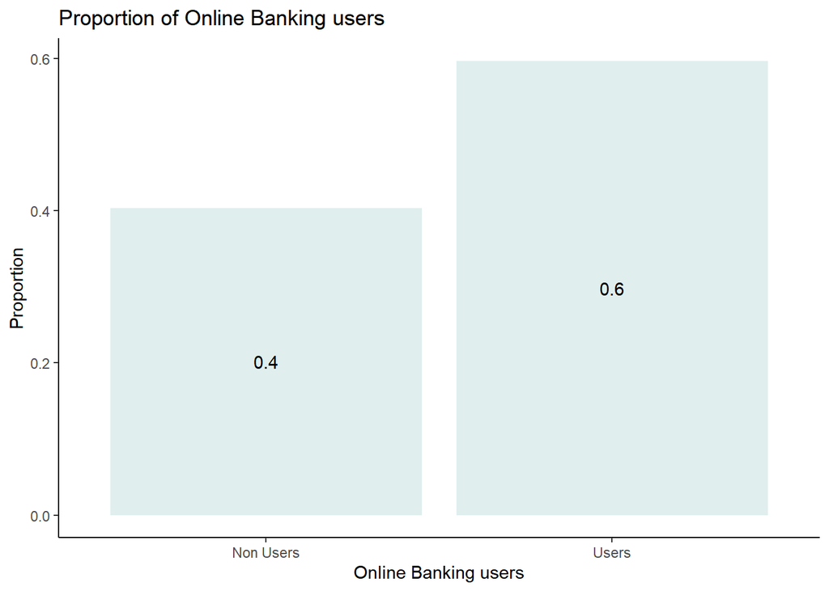

```r
ggplot(UniversalBank, aes(x=Online, y=..prop..,group = 1)) +
  geom_bar(fill="azure2") +
  theme_classic() +
  geom_text(aes(label=round(..prop..,2)),stat = "count",
            position = position_stack(vjust=0.5)) +
  labs(x="Online Banking users",y = 'Proportion',title = "Proportion of Online Banking users") +
  scale_x_discrete(labels = c("Non Users","Users"))
```

From the above graph we can infer that around 60% of population using online banking services, and remaining 40% not opted for it.

Proportion of Credit Card users

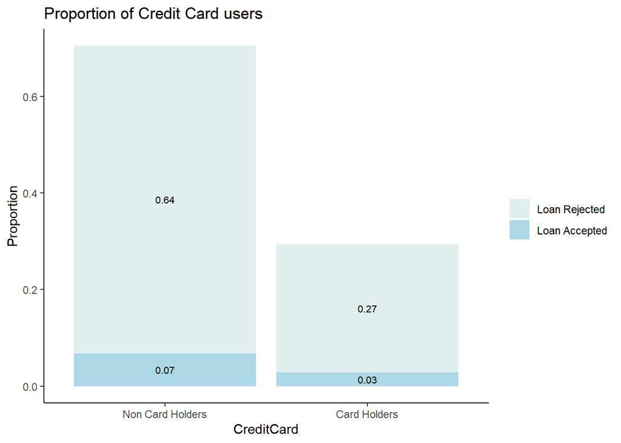

```r
as.data.frame(prop.table(table(UniversalBank[c("CreditCard","Personal Loan")]))) %>%
  ggplot(aes(x=CreditCard,y=Freq,fill=Personal.Loan)) + geom_col() +
  geom_text(aes(label=round(Freq,2)),position = position_stack(vjust = 0.5),size=2.8) +
  theme_classic() + labs( y = 'Proportion', title = "Proportion of Credit Card users") +
  scale_x_discrete(labels = c("Non Card Holders","Card Holders")) +
  theme(legend.title = element_blank()) +
  scale_fill_manual(labels = c("Loan Rejected","Loan Accepted"),
                    values = c("azure2","light blue"))
```

Proportion of Online Banking users

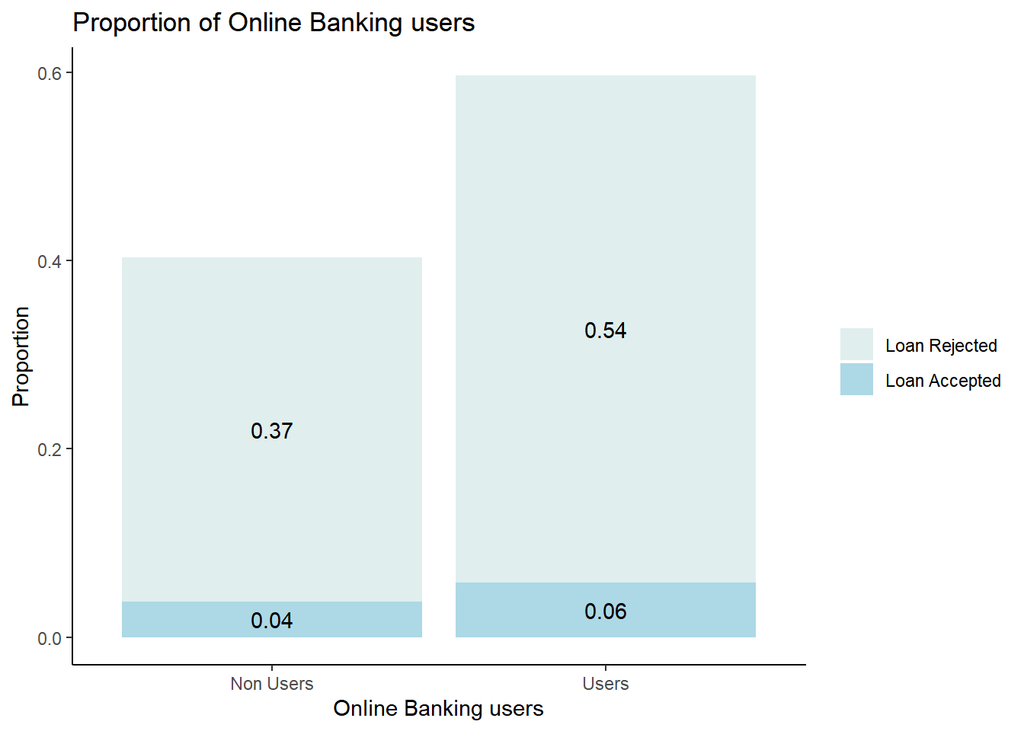

```r
as.data.frame(prop.table(table(UniversalBank[c("Online","Personal Loan")]))) %>%
  ggplot(aes(x=Online,y=Freq,fill=Personal.Loan)) + geom_col() +
  geom_text(aes(label=round(Freq,2)),position = position_stack(vjust = 0.5)) + theme_classic() +
  labs(x="Online Banking users",y = 'Proportion',title = "Proportion of Online Banking users") +
  scale_x_discrete(labels = c("Non Users","Users")) +
  theme(legend.title = element_blank()) +
  scale_fill_manual(labels = c("Loan Rejected","Loan Accepted"),
                    values = c("azure2","light blue"))
```

#### Pre-Processing of data

**Splitting dataset into training (60%) and validation (40%) sets**

```r
set.seed(22)
index <- createDataPartition(UniversalBank$`Personal Loan`, p=0.6, list = FALSE)
UniversalBank_train_df <- UniversalBank[index,]
UniversalBank_val_df <- UniversalBank[-index,]
```

*Q1:* Creating pivot table for the training data using melt() and cast() functions.

```r
UniversalBank_melt <- melt(UniversalBank_train_df, id = c("CreditCard","Personal Loan"),
  variable = "Online")
UniversalBank_cast <- dcast(UniversalBank_melt, CreditCard+`Personal Loan` ~ Online)
(pivottable1 <- UniversalBank_cast %>% select(CreditCard,`Personal Loan`,Online))
```

```
##   CreditCard Personal Loan Online
## 1          0             0   1920
## 2          0             1    204
## 3          1             0    792
## 4          1             1     84
```

```r
(loanacceptance_rate <- (pivottable1[4,"Online"]/sum(pivottable1[4,"Online"],
                                                     pivottable1[3,"Online"])))
```

```
## [1] 0.09589041
```

*Q3:* Creating two separate pivot tables for the training data.

```r
UniversalBank_melt_t1 <- melt(UniversalBank_train_df,id = c("Personal Loan"),variable = "Online")
UniversalBank_cast_t1 <- dcast(UniversalBank_melt_t1, `Personal Loan` ~ Online)
(UniversalBank_cast_t1 %>% select(`Personal Loan`,Online))
```

```
##   Personal Loan Online
## 1             0   2712
## 2             1    288
```

```r
UniversalBank_melt_t2 <- melt(UniversalBank_train_df,id = c("CreditCard"),
  variable = "Online")
UniversalBank_cast_t2 <- dcast(UniversalBank_melt_t2, CreditCard ~ Online)
UniversalBank_cast_t2 %>% select(CreditCard,Online)
```

```
##   CreditCard Online
## 1          0   2124
## 2          1    876
```

*Q4:* Computing quantities.

*Sub Table 1:* with Credit Card(rows) and Personal Loan(columns) details.

```r
(st1 <- table(UniversalBank_train_df[c("CreditCard","Personal Loan")]))
```

```
##           Personal Loan
## CreditCard    0    1
##          0 1920  204
##          1  792   84
```

*Sub Table 2:* with Online(rows) and Personal Loan(columns) details.

```r
(st2 <- table(UniversalBank_train_df[c("Online","Personal Loan")]))
```

```
##       Personal Loan
## Online    0    1
##      0 1074  123
##      1 1638  165
```

*Sub Table 3:* only with Personal Loan count.

```r
(st3 <- table(UniversalBank_train_df["Personal Loan"]))
```

```
##
##    0    1
## 2712  288
```

*i:* P(CC = 1 | Loan = 1)

```r
(q1_prob <- (st1[2,2]/(st1[2,2] + st1[1,2])) * 100)
```

```
## [1] 29.16667
```

[84 / (84 + 204) = 29.16%]

*ii:* P(Online = 1 | Loan = 1)

```r
(q2_prob <- (st2[2,2]/(st2[2,2] + st2[1,2])) * 100)
```

```
## [1] 57.29167
```

[165 / (165 + 123) = 57.29%]

*iii:* P(Loan = 1)

```r
(q3_prob <- (st3[2]/(st3[2] + st3[1])) * 100)
```

```
##   1
## 9.6
```

[288 / (288 + 2712) = 9.6%]

*iv:* P(CC = 1 | Loan = 0)

```r
(q4_prob <- (st1[2,1]/(st1[2,1] + st1[1,1])) * 100)
```

```
## [1] 29.20354
```

[792 / (792 + 1920) = 29.20%]

*v:* P(Online = 1 | Loan = 0)

```r
(q5_prob <- (st2[2,1]/(st2[2,1] + st2[1,1])) * 100)
```

```
## [1] 60.39823
```

[1638 / (1638 + 1074) = 60.39%]

*vi:* P(Loan = 0)

```r
(q6_prob <- (st3[1]/(st3[1] + st3[2])) * 100)
```

```
##    0
## 90.4
```

[2712 / (2712 + 288) = 90.4%]

*Q5:* Using naive Bayes probability to compute P(Loan = 1 | CC = 1,Online = 1).

```r
(nb_prob <- (q1_prob * q2_prob * q3_prob) / ((q1_prob * q2_prob * q3_prob) +
 (q4_prob * q5_prob * q6_prob)))
```

```
##          1
## 0.09140916
```

[((84 / (84 + 204))*(165 / (165 + 123))*(288 / (288 + 2712)))/((84 / (84 + 204))*(165 / (165 + 123))*(288 / (288 + 2712)) + (792 / (792 + 1920))*(1638 / (1638 + 1074))*(2712 / (2712 + 288))) = 9.14%]

*Q6:* Comparing above value with the one obtained from the pivot table in (B).

*Q7:* Using naive Bayes model for computing P(Loan = 1 | CC = 1, Online = 1)

```r
# Build a naive Bayes classifier
nb_train <-  UniversalBank_train_df
nb_test <- UniversalBank_val_df
nb_model <-  naiveBayes(`Personal Loan`~.,data=nb_train)
```

**priori probabilities of Personal Loan**

```r
prop.table(nb_model$apriori)
```

```
## Y
##     0     1
## 0.904 0.096
```

**Conditional probabilities of CreditCard**

```r
nb_model$tables$CreditCard
```

```
##    CreditCard
## Y           0         1
##   0 0.7079646 0.2920354
##   1 0.7083333 0.2916667
```

**Conditional probabilities of Online**

```r
nb_model$tables$Online
```

```
##    Online
## Y           0         1
##   0 0.3960177 0.6039823
##   1 0.4270833 0.5729167
```

From the above results we can see that priori probabilities of naive Bayes wrt loan acceptance(1) is **0.096** which is almost similar to the question 5.

Now, using the nb_model on the test set

```r
predictions_prob <- predict(nb_model, nb_test)
```

**Confusion Matrix of nb_model**

```r
confusionMatrix(nb_test$`Personal Loan`, predictions_prob)
```

```
## Confusion Matrix and Statistics
##
##           Reference
## Prediction    0    1
##          0 1645  163
##          1   80  112
##
##                Accuracy : 0.8785
##                  95% CI : (0.8634, 0.8925)
##     No Information Rate : 0.8625
##     P-Value [Acc > NIR] : 0.01914
##
##                   Kappa : 0.4133
##
##  Mcnemar's Test P-Value : 1.438e-07
##
##             Sensitivity : 0.9536
##             Specificity : 0.4073
##          Pos Pred Value : 0.9098
##          Neg Pred Value : 0.5833
##              Prevalence : 0.8625
##          Detection Rate : 0.8225
##    Detection Prevalence : 0.9040
##       Balanced Accuracy : 0.6804
##
##        'Positive' Class : 0
##
```

**ROC Curve**

```r
predictions_prob1 <- predict(nb_model, nb_test, type = "raw")
roc(nb_test$`Personal Loan`, predictions_prob1[,2])
```

```
##
## Call:
## roc.default(response = nb_test$`Personal Loan`, predictor = predictions_prob1[,     2])
##
## Data: predictions_prob1[, 2] in 1808 controls (nb_test$`Personal Loan` 0) < 192 cases (nb_test$`Personal Loan` 1).
## Area under the curve: 0.9202
```

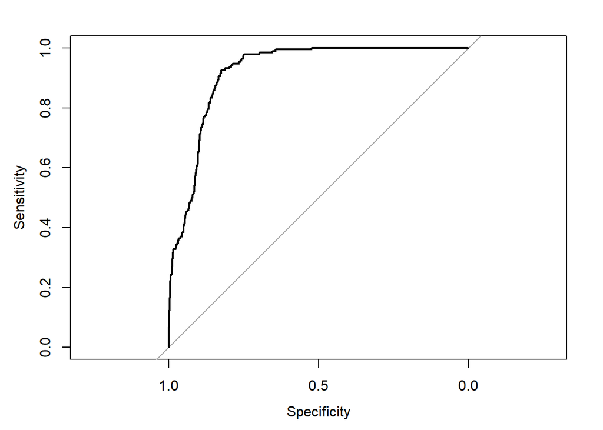

```r
plot.roc(nb_test$`Personal Loan`, predictions_prob1[,2])
```